# ETC5521 Diving Deeper into Data Exploration: Assignment 1

Author

HengHsieh Chang

Published

August 18, 2025

## 🛠️ Exercises

```r
# Install and load orcas package
remotes::install_github("jadeynryan/orcas")

library(orcas)
orcas <- orcas::cwr_tidy

# Save the data locally
save(orcas, file="orcas.rda")

# Load required libraries
library(tidyverse)
library(dplyr)
library(ggplot2)
library(lubridate)
library(knitr)
library(kableExtra)
library(plotly)

# Load the orcas dataset
load("orcas.rda")

# Display whole data structure
glimpse(orcas)
```

[output not shown]

> Data Processing Overview：The dataset was imported from the `orcas` package and preprocessed by standardizing time fields, cleaning text entries, and separating multi-value fields (e.g., vessels, observers, pods) into individual rows. These steps enabled more granular and accurate analysis.

## Question 1 : Temporal Pattern Analysis of Orca Encounters

### **1. Time frame of data collection**

```r
# Calculate the overall time span of the dataset
time_range <- orcas_tidy %>%
  summarise(
    start_date = min(date, na.rm = TRUE),
    end_date = max(date, na.rm = TRUE),
    total_days = as.numeric(end_date - start_date)
  )

time_range%>%
  kable(caption = "Time Range of Orca Dataset",
        align = "l", format = "html") %>%
  kable_styling(full_width = FALSE)%>%
  row_spec(0, bold = TRUE)
```

Time Range of Orca Dataset

| start_date | end_date | total_days |
| --- | --- | --- |
| 2017-01-05 | 2024-10-06 | 2831 |

**Data Overview:**

The orca encounter dataset spans 8 years ( January 2017 to October 2024), providing 2831 days of comprehensive observation data.

### **2. Seasonal patterns by Month**

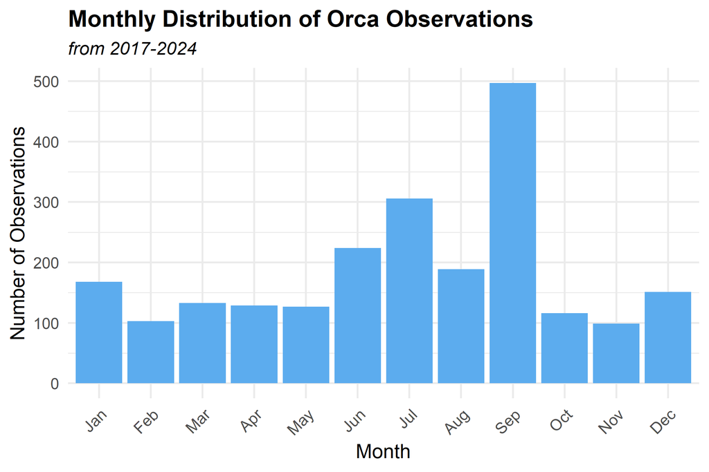

Figure 1: Monthly Distribution of Orca Observations between 2017-2024

```r
# Observations by month to identify peak seasons
orcas_tidy %>%
  filter(!is.na(date)) %>%
  mutate(month = lubridate::month(date, label = TRUE, abbr = TRUE, locale = "C")) %>%
  count(month) %>%
  ggplot(aes(x = month, y = n)) +
  geom_col(fill = "steelblue2") +
  labs(title = "Monthly Distribution of Orca Observations",
       subtitle = "from 2017-2024",
       x = "Month",
       y = "Number of Observations") +
  theme_minimal(base_size = 12)+
  theme(
    axis.text.x = element_text(angle = 45, hjust = 1),
    plot.title = element_text(size = 14, face = "bold"),
    plot.subtitle = element_text(size = 11, face = "italic"),
    axis.title = element_text(size = 12)
  )
```

### **3. Seasonal patterns by Year**

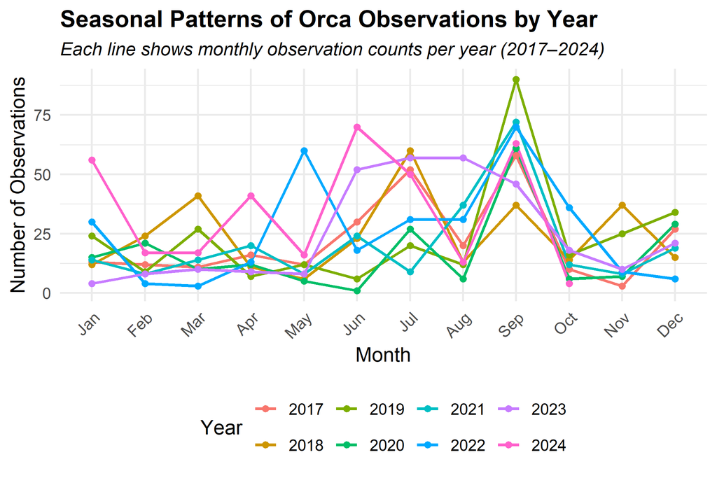

Figure 2: Annually Distribution of Orca Observations, each line shows monthly observation counts per year (2017–2024)

```r
# Analyze how monthly patterns vary across different years
orcas_tidy %>%
  filter(!is.na(date)) %>%
  mutate(
    year = year(date),
    month = month(date, label = TRUE, abbr = TRUE, locale = "C")
  ) %>%
  count(year, month) %>%
  ggplot(aes(x = month, y = n, group = year, color = factor(year))) +
  geom_line(linewidth = 0.8) +
  geom_point(size = 1.5) +
  labs(
    title = "Seasonal Patterns of Orca Observations by Year",
    subtitle = "Each line shows monthly observation counts per year (2017–2024)",
    x = "Month",
    y = "Number of Observations",
    color = "Year"
  ) +
  theme_minimal(base_size = 12) +
  theme(
    axis.text.x = element_text(angle = 45, hjust = 1),
    plot.title = element_text(size = 14, face = "bold"),
    plot.subtitle = element_text(size = 11, face = "italic"),
    axis.title = element_text(size = 12),
    legend.position = "bottom"
  )
```

### **4. Encounter duration analysis**

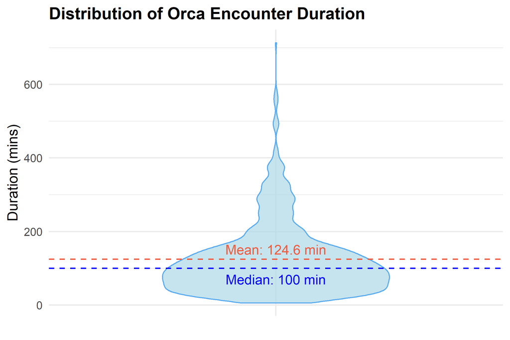

Figure 3: Distribution of Orca Encounter Duration during 2017-2024

```r
enc_duration <- orcas_tidy %>%
  summarise(
    mean_duration = mean(duration_min, na.rm = TRUE),
    median_duration = median(duration_min, na.rm = TRUE)
    )

# Create violin plot
ggplot(orcas_tidy,aes(x = "", y = duration_min)) +
  geom_violin(fill = "lightblue", color = "steelblue2", alpha = 0.7, width = 0.6) +
  # Add the mean and median line
  geom_hline(yintercept = enc_duration$mean_duration,
             color = "tomato2",
             linewidth = 0.6, ,
             linetype = "dashed")+
  geom_hline(yintercept = enc_duration$median_duration,
             color = "blue",
             linewidth = 0.6,
             linetype = "dashed") +
  annotate("text",
           x = 1,
           y = enc_duration$mean_duration,
           label = paste0("Mean: ", round(enc_duration$mean_duration,1), " min"),
           color = "tomato2",
           vjust = -0.5,
           size = 4) +
  annotate("text",
           x = 1,
           y = enc_duration$mean_duration,
           label = paste0("Median: ", round(enc_duration$median_duration,1), " min"),
           color = "blue",
           vjust = 2.5,
           size = 4) +
  labs(
    title = "Distribution of Orca Encounter Duration",
    y = "Duration (mins)",
    x = NULL
  ) +
  theme_minimal(base_size = 12)+
  theme(
    plot.title = element_text(size = 14, face = "bold"),
    axis.title = element_text(size = 12)
  )
```

Figure 3 shows the encounter durations average 124.6 (median: 100 minutes), indicating substantial observation periods suitable for detailed behavioral analysis. The right-skewed distribution shows that most encounters last 1-3 hours, with a few extending beyond 8 hours.

## Question 2 : Spatial Pattern Analysis of Orca Encounters

### **1. Where are these encounters happening?**

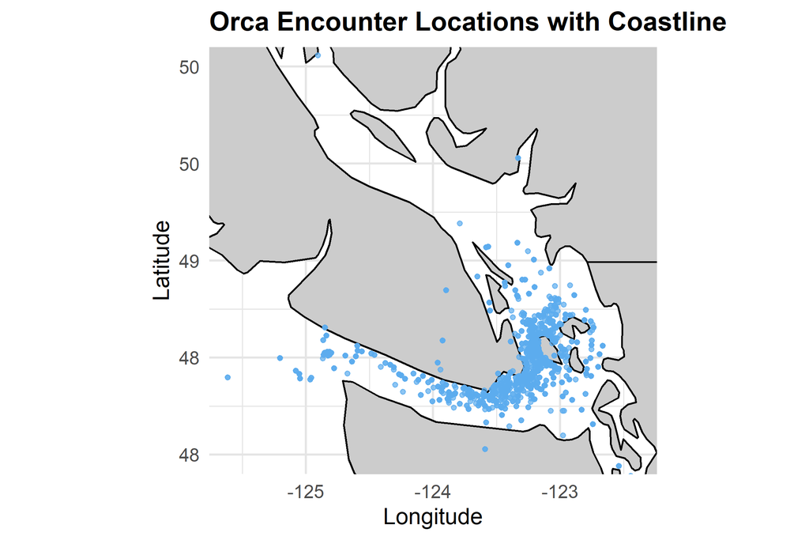

Figure 4: Orca encounter locations plotted against the coastline of British Columbia.

```r
library(maps)

map_orcas_tidy <- orcas_tidy %>%
  filter(!is.na(begin_latitude), !is.na(begin_longitude),
         !is.na(end_latitude), !is.na(end_longitude))

# Get the latitude–longitude range
invisible(range(orcas_tidy$begin_latitude, na.rm = TRUE))
invisible(range(orcas_tidy$begin_longitude, na.rm = TRUE))

ggplot() +
    borders("world", colour = "black", fill = "grey80") +
    geom_point(data = map_orcas_tidy,
               aes(x = begin_longitude, y = begin_latitude),
               color = "steelblue2",
               alpha = 0.7,
               size = 1) +
    coord_quickmap(xlim = c(-125.6, -122.4),
                   ylim = c(48, 50)) +
    labs(
      title = "Orca Encounter Locations with Coastline",
      x = "Longitude",
      y = "Latitude"
    ) +
    theme_minimal(base_size = 12)+
  theme(
    plot.title = element_text(size = 14, face = "bold"),
    axis.title = element_text(size = 12),
    axis.text = element_text(size = 10),
    panel.grid = element_line(color = "gray90")
  )
```

As shown in Figure 4, most orca encounters are primarily concentrated in the inland coastal waters between Vancouver Island and mainland British Columbia, particularly within the **latitude range of 48°- 49.5°N and longitude range of 123°- 125°W**. This area includes the southern Gulf Islands and San Juan Island, as shown in the map.

Most activity is clustered in protected inland waterways rather than the open Pacific Ocean, forming dense, consistent hotspots. These spatial patterns suggest relatively stable orca habitat preferences across years, especially within narrow channels and coastal zones.

### **2. Vessel movement patterns analysis**

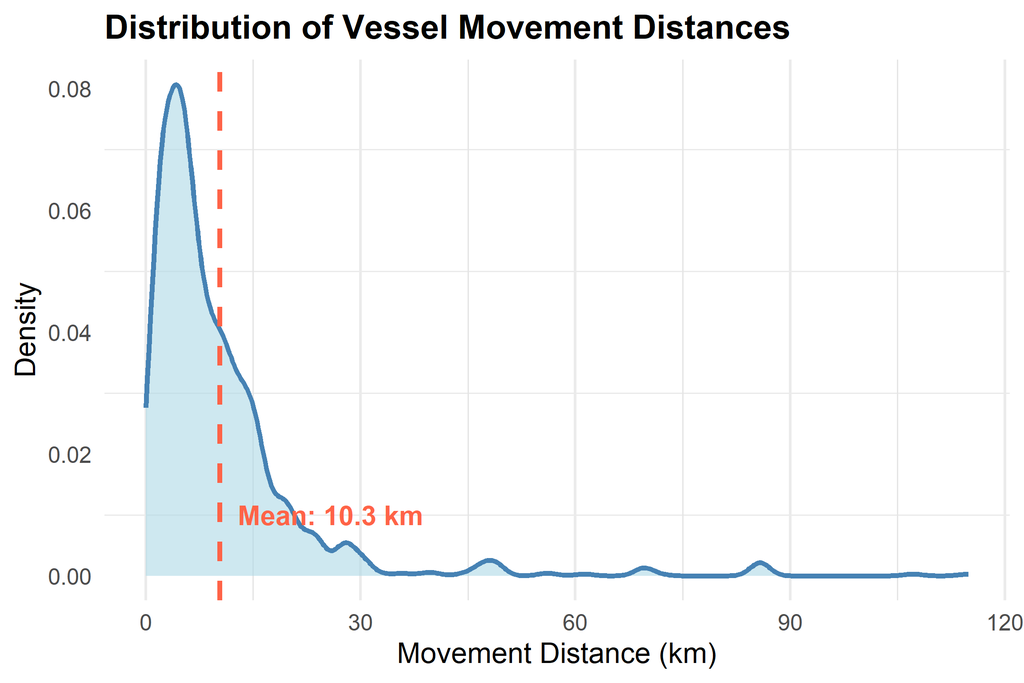

Figure 5: Density distribution of vessel movement distances with mean indicated

```r
library(geosphere)

map_orcas_tidy <- orcas_tidy %>%
  filter(!is.na(begin_latitude), !is.na(begin_longitude),
         !is.na(end_latitude), !is.na(end_longitude)) %>%
  mutate(
    move_distance_km = distHaversine(
      p1 = cbind(begin_longitude, begin_latitude),
      p2 = cbind(end_longitude, end_latitude)
    ) / 1000)

# Calculate the average movement distance
mean_distance <- mean(map_orcas_tidy$move_distance_km, na.rm = TRUE)

# Create density plot
ggplot(map_orcas_tidy, aes(x = move_distance_km)) +
  geom_density(fill = "lightblue",
               color = "steelblue",
               alpha = 0.6,
               linewidth = 1) +
  geom_vline(xintercept = mean_distance,
             linetype = "dashed",
             color = "tomato",
             linewidth = 1) +
  annotate("text",
           x = mean_distance,
           y = 0.01,
           label = paste0("Mean: ", round(mean_distance, 1), " km"),
           hjust = -0.1,
           color = "tomato",
           size = 4,
           fontface = "bold") +
  labs(title = "Distribution of Vessel Movement Distances",
       x = "Movement Distance (km)",
       y = "Density") +
  theme_minimal(base_size = 12) +
  theme(
    plot.title = element_text(size = 14, face = "bold"),
    axis.title = element_text(size = 12),
    panel.grid.minor.x = element_line(color = "grey90"),
    panel.grid.major.y = element_blank()
  )
```

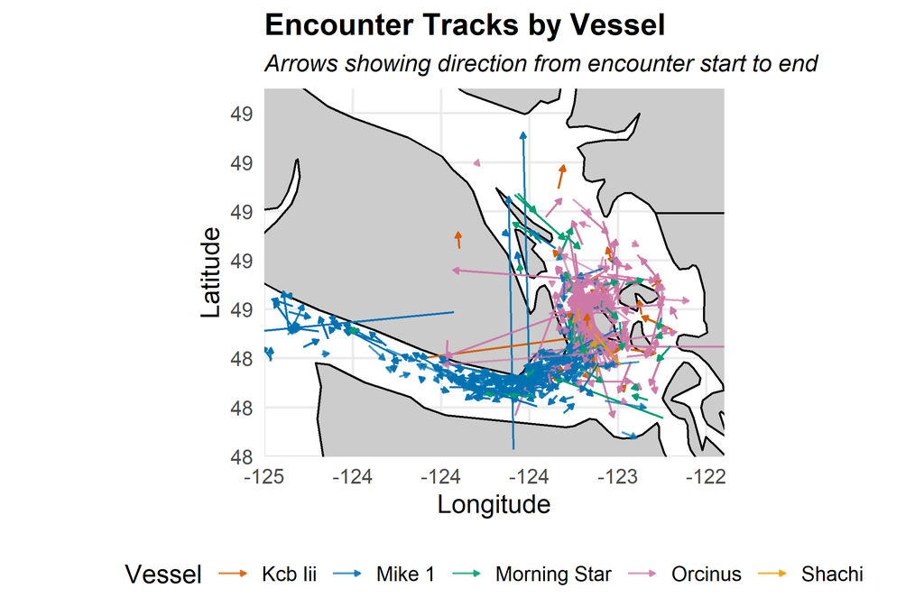

Figure 6: Encounter tracks by top 5 vessels with direction arrows

```r
library(sf)

# Extract the top 5 vessels
top_vessel_track <- map_orcas_tidy %>%
  filter(!is.na(vessel)) %>%
  count(vessel, sort = TRUE) %>%
  slice_max(n, n = 5) %>%
  pull(vessel)

# Create vessel track map
map_orcas_tidy %>%
  filter(vessel %in% top_vessel_track) %>%
  ggplot() +
  borders("world", colour = "black", fill = "grey80") +
  geom_segment(aes(x = begin_longitude, y = begin_latitude,
                   xend = end_longitude, yend = end_latitude,
                   color = vessel),
               arrow = arrow(type = "closed", length = unit(0.1, "cm")),
               linewidth = 0.5, alpha = 0.7) +
  coord_sf(xlim = c(-125, -122.4),
                 ylim = c(48, 49.5))+
  labs(
    title = "Encounter Tracks by Vessel",
    subtitle = "Arrows showing direction from encounter start to end",
    x = "Longitude",
    y = "Latitude",
    color = "Vessel"
  ) +
  theme_minimal(base_size = 12) +
  theme(
    legend.position = "bottom",
    legend.title.align = 0.5,
    aspect.ratio = 0.8,
    plot.title = element_text(size = 14, face = "bold"),
    plot.subtitle = element_text(size = 11, face = "italic"),
    axis.title = element_text(size = 12),
  )+
  scale_x_continuous(expand = c(0, 0)) +
  scale_y_continuous(expand = c(0, 0))
```

Because the full set of vessel tracks is visually cluttered, we refined the visualization by filtering to the top 5 most active vessels.

Based on the Figure 5 and Figure 6 , the analysis shows that vessel movements pattern during encounters are mostly short and localized, with an average movement distance of 10.3 km. This suggests vessels either find whales quickly or operate in small, concentrated areas.

The tracks reveal clear directional patterns with arrows indicating movement from the start to the end points of each encounter. Different vessels like Kcb III, Mike 1, and Orcinus showing distinct tracking behaviors, that some follow tight, clustered, localized paths near whale pods, often moving in relatively short, linear routes.

Repeated use of similar paths indicates routine patrolling or predictable whale locations in these areas.

## Question 3 : Analysis of Encounters by Vessels and Observers

```r
# Clean and standardizing the pod column
orcas_tidy <- orcas_tidy %>%
  mutate(
    pods_or_ecotype = str_replace_all(pods_or_ecotype, "(?i)\\s+[Aa]nd\\s+", ","),
    pods_or_ecotype = str_replace_all(pods_or_ecotype, "/", ","),
    pods_or_ecotype = str_replace_all(pods_or_ecotype, "&", ","),
    pods_or_ecotype = str_replace_all(pods_or_ecotype, "\\s*\\([^\\)]+\\)", ""),
    pods_or_ecotype = case_when(
      str_detect(pods_or_ecotype,
                 regex("Bigg.?s.*killer.*whales",
                       ignore_case = TRUE)) ~ "Bigg's killer whales",
      str_detect(pods_or_ecotype,
                 regex("Bigg's$",
                       ignore_case = TRUE)) ~ "Bigg's killer whales",
      str_detect(pods_or_ecotype,
                 regex("Transient",
                       ignore_case = TRUE)) ~ "Bigg's killer whales",
      TRUE ~ pods_or_ecotype
    ),
    pods_or_ecotype = str_replace_all(pods_or_ecotype, "(?i)\\s*pods?\\s*", ""),
    pods_or_ecotype = if_else(
      str_detect(pods_or_ecotype,
                 regex("^Bigg's(\\s|$)",
                       ignore_case = TRUE)),
      pods_or_ecotype,
      str_replace_all(pods_or_ecotype, "'[sS]", ",")
    ),
    pods_or_ecotype = str_replace(pods_or_ecotype, "^(?i)And\\s+", ""),
    pods_or_ecotype = str_squish(pods_or_ecotype),
    pods_or_ecotype = str_squish(pods_or_ecotype),
  )%>%
  separate_rows(pods_or_ecotype, sep = ",") %>%
  mutate(pods_or_ecotype = str_trim(pods_or_ecotype)) %>%
  filter(pods_or_ecotype != "")
```

### **1. Which Orca Pods Are Seen the Most Often?**

```r
# Identify which pods are encountered most often
top_pod <- orcas_tidy %>%
  count(pods_or_ecotype, sort = TRUE) %>%
  slice_max(n, n = 10, with_ties = FALSE)

top_pod %>%
  rename(`Pod / Ecotype` = pods_or_ecotype,
         `Encounters` = n) %>%
  kable(caption = "Top 10 Frequently Observed Orcas",
        align = "l", format = "html") %>%
  kable_styling(full_width = FALSE)%>%
  row_spec(0, bold = TRUE)
```

Table 1: The most frequently encountered orca pods from 2017-2024

Top 10 Frequently Observed Orcas

| Pod / Ecotype | Encounters |
| --- | --- |
| Bigg's killer whales | 979 |
| J | 568 |
| L | 293 |
| K | 257 |
| L87 | 31 |
| T124c | 12 |
| L4s | 9 |
| T2cs | 9 |
| Southern Resident Killer Whales | 8 |
| L26s | 7 |

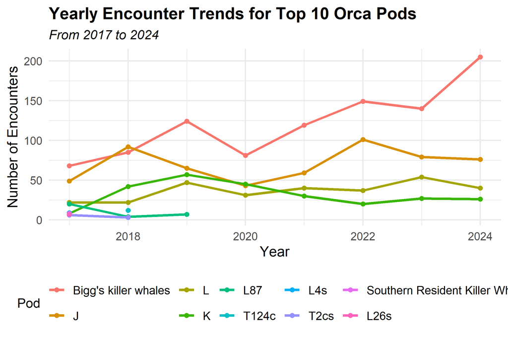

Figure 7: Yearly Encounter Trends for Top 10 Orca Pods (2017–2024)

```r
# Calculate the encounters of top pods by year
top_pod_yearly <- orcas_tidy %>%
filter(pods_or_ecotype %in% top_pod$pods_or_ecotype, !is.na(date)) %>%
mutate(year = lubridate::year(date),
       pods_or_ecotype = factor(pods_or_ecotype,
                                levels = top_pod$pods_or_ecotype)
) %>%
count(year, pods_or_ecotype)

# Plot line chart to display annual trend
ggplot(top_pod_yearly, aes(x = year, y = n, color = pods_or_ecotype)) +
geom_line(linewidth = 1) +
geom_point() +
labs(
title = "Yearly Encounter Trends for Top 10 Orca Pods",
subtitle = "From 2017 to 2024",
x = "Year",
y = "Number of Encounters",
color = "Pod"
) +
theme_minimal(base_size = 12) +
theme(
  plot.title = element_text(face = "bold", size = 14),
  plot.subtitle = element_text(face = "italic", size = 11),
  legend.position = "bottom",
  legend.title = element_text(size = 11),
  legend.text = element_text(size = 10)
  )
```

From Table 1 we can know **Bigg’s killer whales were the most frequently observed ecotype**, followed by Southern Resident groups include J, L and K pods. Same whale groups consistently appear across multiple years

### **2. Most active vessels and observers in Orca Encounters**

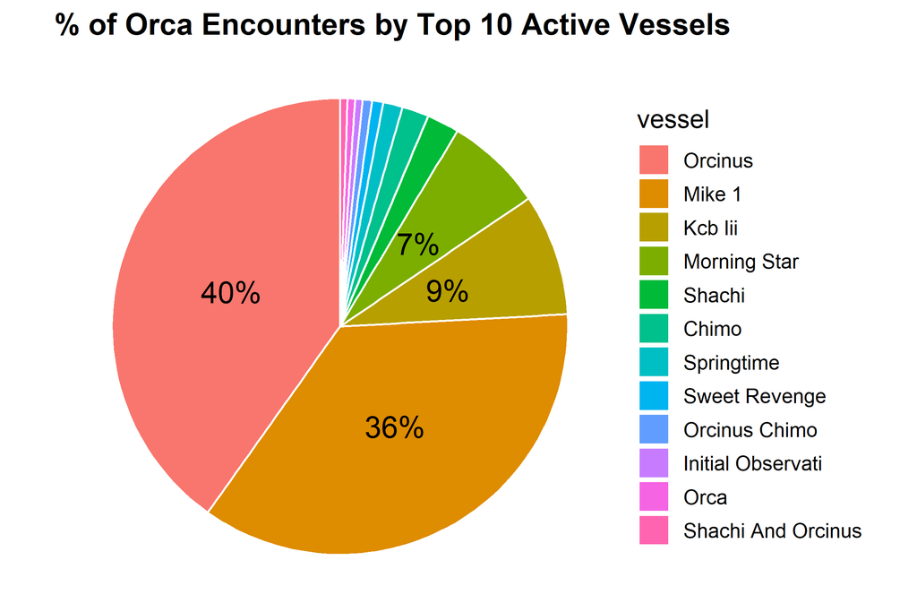

Figure 8: Proportion of Orca Encounters by Top 10 Active Vessels (2017–2024)

```r
# Count total encounters per vessel
top_vessel <- orcas_tidy %>%
  filter(!is.na(vessel)) %>%
  count(vessel, sort = TRUE) %>%
  slice_max(n, n = 10)%>%
  mutate(
    share = n / sum(n),
    label = paste0(vessel, "\n", round(share * 100), "%")
  )%>%
  arrange(desc(share)) %>%
  mutate(vessel = factor(vessel, levels = unique(vessel)),
         label = ifelse(share > 0.05,
                        scales::percent(share, accuracy = 1), ""))

# Create pie chart
ggplot(top_vessel, aes(x = "", y = share, fill = vessel)) +
  geom_col(width = 1, color = "white") +
  coord_polar(theta = "y") +
  geom_text(aes(label = label),
            position = position_stack(vjust = 0.5),
            size = 5, color = "black") +
  labs(title = "% of Orca Encounters by Top 10 Active Vessels") +
  theme_void(base_size = 12) +
  theme(legend.position = "right",
        plot.title = element_text(face = "bold", size = 14))
```

As shown in Figure 8, the **vessels Orcinus and Mike 1 stand out as the most active vessels**, collectively accounting for **nearly 80%** of all orca encounters. Their frequent involvement shows their pivotal role in data collection and long-term monitoring efforts.

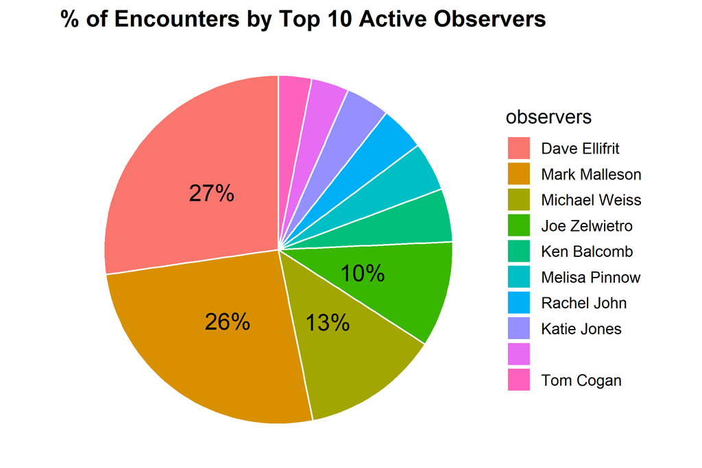

Figure 9: Proportion of Orca Encounters by Top 10 Active observers (2017–2024)

```r
# Count encounters by observer
top_observer <- orcas_tidy %>%
  filter(!is.na(observers)) %>%
  count(observers, sort = TRUE) %>%
  slice_max(n, n = 10)  %>%
  mutate(
    share = n / sum(n),
    label = ifelse(share > 0.05,
                   scales::percent(share, accuracy = 1), ""),
    observers = factor(observers, levels = observers[order(-share)]))

# Create pie chart
ggplot(top_observer, aes(x = "", y = share, fill = observers)) +
  geom_col(width = 1, color = "white") +
  coord_polar(theta = "y") +
  geom_text(aes(label = label),
            position = position_stack(vjust = 0.5),
            size = 5, color = "black") +
  labs(title = "% of Encounters by Top 10 Active Observers") +
  theme_void(base_size = 12) +
  theme(legend.position = "right",
        plot.title = element_text(face = "bold", size = 14))
```

As shown in Figure 9, more than half of all documented orca encounters were contributed by a small core of dedicated and highly active observers, especially Dave Ellifrit and Mark Malleson. This reflects strong continuity and expertise in long-term data collection.

### **3. Vessel-Pod relationship analysis**

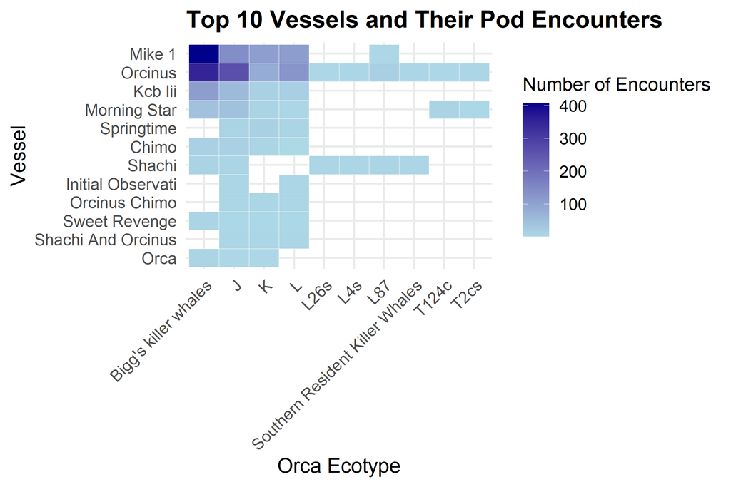

Figure 10: encounter frequencies between top 10 vessels and most observed orca pods

```r
# Analyze which vessels encounter which pod types most frequently
vessel_pod_encounters <- orcas_tidy %>%
  filter(vessel %in% top_vessel$vessel,
         pods_or_ecotype %in% top_pod$pods_or_ecotype) %>%
  count(vessel, pods_or_ecotype, name = "encounters")

# Plot heatmap showing vessel-pod encounter patterns
ggplot(vessel_pod_encounters, aes(x = pods_or_ecotype,
                           y = reorder(vessel, encounters),
                           fill = encounters)) +
  geom_tile(color = "white") +
  scale_fill_gradient(low = "lightblue", high = "darkblue") +
  labs(
    title = "Top 10 Vessels and Their Pod Encounters",
    x = "Orca Ecotype",
    y = "Vessel",
    fill = "Number of Encounters"
  ) +
  theme_minimal(base_size = 12) +
  theme(
    axis.text.x = element_text(angle = 45, hjust = 1),
    plot.title = element_text(face = "bold", size = 14),
    legend.title = element_text(size = 11),
    legend.text = element_text(size = 10))
```

As shown in Figure 10, the most active vessels, especially Orcinus and Mike 1, encountered a wide range of orca pods. Orcinus had high encounters with all major groups, showing its broad research focus. Mike 1 also had frequent encounters, especially with Bigg’s and J,K,L pods, suggesting a focus on certain ecotypes. Other vessels like Kcb III and Morning Star had fewer total encounters but were more focused on specific pods.

Overall, the data shows a clear pattern that some vessels specialize in certain pods, while others provide broad coverage, helping build the record of orca populations.

### **4. Vessel Observation Patterns of Orca Pods**

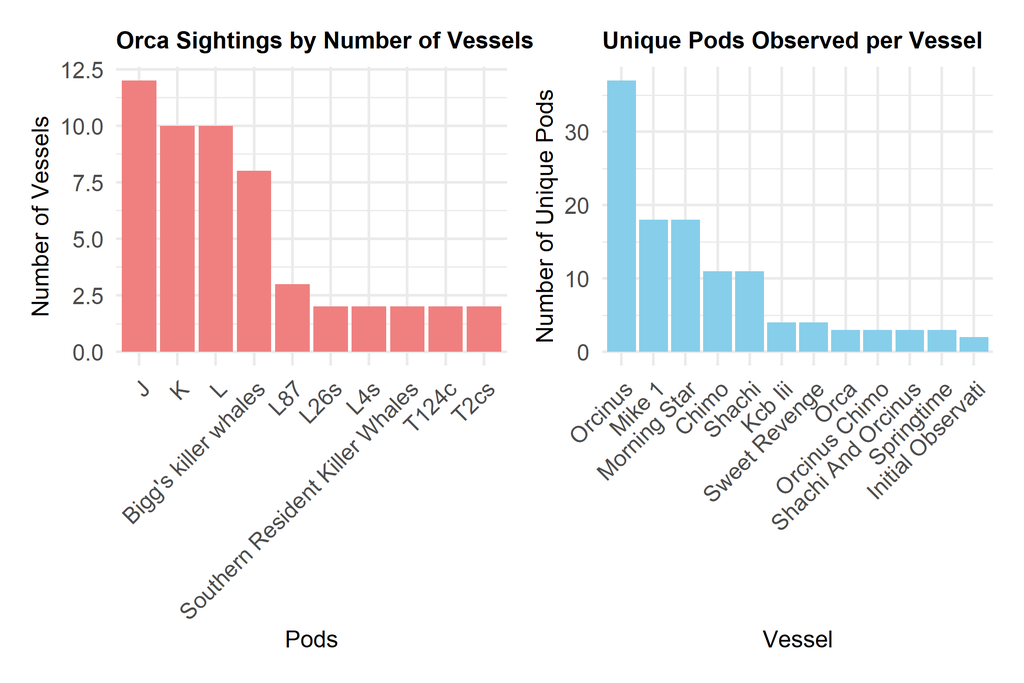

Figure 11: Left: The number of top vessels observing each orca pod highlights which pods are most consistently encountered across multiple vessels. Right: Variation in the number of unique pods recorded by each vessel reflects differing research focuses and observational breadth.

```r
library(patchwork)
pod_vessel_overlap <- orcas_tidy %>%
  filter(vessel %in% top_vessel$vessel,
         pods_or_ecotype %in% top_pod$pods_or_ecotype) %>%
  distinct(pods_or_ecotype, vessel) %>%
  count(pods_or_ecotype, name = "num_vessels") %>%
  arrange(desc(num_vessels))

p2 <- ggplot(pod_vessel_overlap,
             aes(x = reorder(pods_or_ecotype, -num_vessels),
                 y = num_vessels)) +
  geom_col(fill = "lightcoral") +
  labs(
    title = "Orca Sightings by Number of Vessels",
    x = "Pods",
    y = "Number of Vessels"
  ) +
  theme_minimal(base_size = 12) +
  theme(
    axis.text.x = element_text(angle = 45, hjust = 1),
    plot.title = element_text(size = 10, face = "bold"),
    axis.title = element_text(size = 10))


vessel_diversity <- orcas_tidy %>%
  filter(vessel %in% top_vessel$vessel) %>%
  distinct(vessel, pods_or_ecotype) %>%
  count(vessel, name = "unique_pods_seen") %>%
  arrange(desc(unique_pods_seen))

observer_diversity <- orcas_tidy %>%
  filter(observers %in% top_observer$observers) %>%
  distinct(observers, pods_or_ecotype) %>%
  count(observers, name = "unique_pods_seen") %>%
  arrange(desc(unique_pods_seen))

p3 <- ggplot(vessel_diversity,
             aes(x = reorder(vessel, -unique_pods_seen),
                 y = unique_pods_seen)) +
  geom_col(fill = "skyblue") +
  labs(
    title = "Unique Pods Observed per Vessel",
    x = "Vessel",
    y = "Number of Unique Pods"
  ) +
  theme_minimal(base_size = 12) +
  theme(
    axis.text.x = element_text(angle = 45, hjust = 1),
    plot.title = element_text(size = 10, face = "bold"),
    axis.title = element_text(size = 10))

p2 + p3 + plot_layout(ncol = 2, widths = c(1, 1))
```

The most active vessels not only contributed a high number of encounters but also displayed broad diversity in the pods they observed. As shown in Figure 11, J, K, and L pods were the most consistently observed by multiple vessels, indicating they are frequent and accessible groups.

Meanwhile, Figure 11 reveals that vessels like Orcinus and Mike 1 not only led in encounter counts but also encountered the widest range of unique pods, reflecting both operational intensity and wide-ranging survey efforts.

### **5. Average Encounter Duration per Vessel**

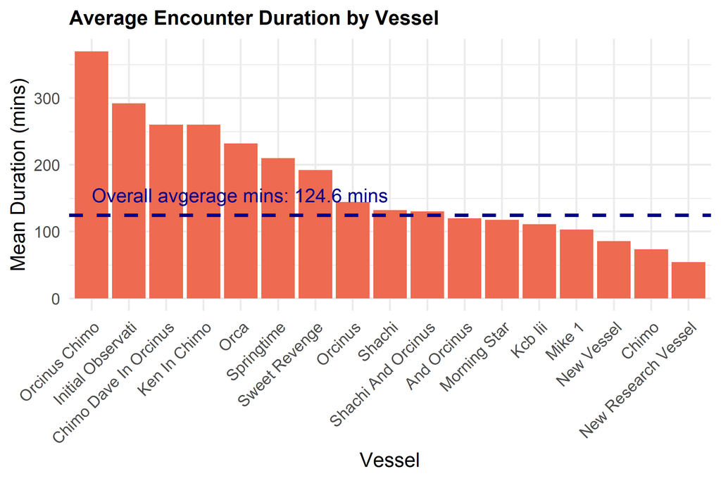

Figure 12: Average encounter duration by vessel, highlighting variation in research effort.

```r
vessel_mean_dur <- enc_duration$mean_duration

# Calculate the stats of vessel encounter duration
vessel_duration <- orcas_tidy %>%
  filter(!is.na(vessel), !is.na(duration_min)) %>%
  group_by(vessel) %>%
  summarise(mean_duration = mean(duration_min, na.rm = TRUE),
            max_duration = max(duration_min, na.rm = TRUE),
            long_encounters  = sum(duration_min > vessel_mean_dur, na.rm = TRUE),
            num_encounters = n(),
            .groups = "drop"
  ) %>%
  # Only vessels with 5+ encounters
  filter(num_encounters >= 5) %>%
  arrange(desc(mean_duration))

# Create the bar chart
ggplot(vessel_duration, aes(x = reorder(vessel, -mean_duration),
                            y = mean_duration)) +
  geom_col(fill = "coral2") +
  geom_hline(yintercept = vessel_mean_dur,
             linetype = "dashed",
             linewidth = 1,
             color = "blue4") +
  annotate("text", x = 1, y = vessel_mean_dur + 30,
           label = paste0("Overall avgerage mins: ",
                          round(vessel_mean_dur, 1), " mins"),
           hjust = 0, size = 4, color = "blue4") +
  labs(
    title = "Average Encounter Duration by Vessel",
    x = "Vessel",
    y = "Mean Duration (mins)"
  ) +
  theme_minimal(base_size = 12) +
  theme(
    axis.text.x = element_text(angle = 45, hjust = 1),
    plot.title = element_text(size = 12, face = "bold"),
    axis.title = element_text(size = 12))
```

*Some vessel names, such as Orcinus Chimo remain partially merged due to data cleaning limits, but this does not impact the overall analysis.*

In contrast, high-activity vessels like Mike 1 and Kcb III had shorter average durations, indicating more frequent but quicker encounters.

This suggests that different vessels employ different research styles, with some focusing on in-depth encounters and others prioritizing broad coverage.

## Question 4 : Common Words analysis

```r
library(tidytext)
library(stopwords)
data("stop_words")

# Word Tokenize
orcas_words <- orcas_tidy %>%
  select(encounter_summary) %>%
  filter(!is.na(encounter_summary))%>%
  unnest_tokens(word, encounter_summary)%>%
  filter(!word %in% stop_words$word,
         !word %in% c("whale", "whales", "orca", "orcas", "pod", "pods", "encounter"))

# Top 20 Words
top_words <- orcas_words %>%
  count(word, sort = TRUE) %>%
  slice_max(n, n = 20) %>%
  rename(count = n)

top_words%>%
  kable(caption = "Top 20 common words",
        align = "l", format = "html") %>%
  kable_styling(full_width = FALSE)%>%
  row_spec(0, bold = TRUE)
```

Top 20 common words

| word | count |
| --- | --- |
| south | 5108 |
| island | 4787 |
| north | 4744 |
| west | 3666 |
| team | 3388 |
| headed | 3157 |
| heading | 3111 |
| east | 3026 |
| mark | 2806 |
| left | 2711 |
| spread | 2632 |
| strait | 1989 |
| found | 1984 |
| bay | 1888 |
| mile | 1801 |
| juan | 1782 |
| 1 | 1721 |
| dave | 1655 |
| killer | 1616 |
| slowly | 1577 |

**Word Filtering Explanation** :

Common stop words and general terms like *“whale”*, *“orca”*, *“pod”*, and *“encounter”* were removed before analysis. These words appear in almost every summary and do not add useful information. This step helps highlight more specific and meaningful content in the encounter descriptions.

**Summaries of Common Words** :

- The **most common words** in the encounter summaries include **location related terms** like *“south”*, *“north”*, *“island”*, and *“west”*. These words show that observers often describe where the orcas were seen and the direction they were moving.
- **Action words** such as *“headed”*, *“heading”*, and *“left”* are also frequent. This suggests that many summaries include details about orcas movement.
- Some words, like *“team”* and *“mark”*, may refer to people involved in the observations. These are less useful for understanding orcas behavior.
- Depending on the research goal, it may be helpful to remove location names and people’s names to focus more on behavior-related words.

## Resources

The materials used for this report are:

```
  Becker RA, Wilks AR, Brownrigg R, Minka TP, Deckmyn A (2025). _maps: Draw   Geographical Maps_. R package version 3.4.3, <https://github.com/adeckmyn/maps>.
```

```
Wickham H, Averick M, Bryan J, Chang W, McGowan LD, François R,   Grolemund G, Hayes A, Henry L, Hester J, Kuhn M, Pedersen TL, Miller   E, Bache SM, Müller K, Ooms J, Robinson D, Seidel DP, Spinu V,   Takahashi K, Vaughan D, Wilke C, Woo K, Yutani H (2019). “Welcome to   the tidyverse.” _Journal of…
```

```
Pedersen T (2025). _patchwork: The Composer of Plots_. R package version 1.3.1,   https://github.com/thomasp85/patchwork, <https://patchwork.data-imaginist.com>.
```

```
Ryan J (2025). _orcas: Scrape and Visualize Orca Sighting Data_. R package version   0.0.0.9000, commit 08b3808ee4f5c9f1a25cbedea9e9d8316322ed1c,   <https://github.com/jadeynryan/orcas>.
```

```
  Hijmans R (2024). _geosphere: Spherical Trigonometry_. R package version 1.5-20.
```

```
  Benoit K, Muhr D, Watanabe K (2021). _stopwords: Multilingual Stopword Lists_. R   package version 2.3, <https://github.com/quanteda/stopwords>.
```

```
  C. Sievert. Interactive Web-Based Data Visualization with R, plotly, and shiny.   Chapman and Hall/CRC Florida, 2020.
```

```
  Pebesma, E., 2018. Simple Features for R: Standardized Support for Spatial Vector   Data. The R Journal 10 (1), 439-446, https://doi.org/10.32614/RJ-2018-009
```

```
  Garrett Grolemund, Hadley Wickham (2011). Dates and Times Made Easy with lubridate.   Journal of Statistical Software, 40(3), 1-25. URL   https://www.jstatsoft.org/v40/i03/.
```

The links to my use of ChatGPT for help on this assignment are:

- https://chatgpt.com/share/68857a22-debc-8001-bfcc-10552befba4c helped to construct the regex to process the duration variable.
- https://chatgpt.com/share/689dc8d9-8f74-8000-93e0-2ddc283f7bca helped calculate encounter durations using time-format variables.
- https://chatgpt.com/share/68a17e5e-f974-8000-9e89-96775d021bec helped to identify pod name variations referring to the same group and suggested ways to standardize them.
- https://chatgpt.com/share/68a1986b-5f4c-8000-b47c-85bbe20d4c3a helped to clarified that “Bigg’s killer whales,” “Bigg’s Transient killer whales,” and “Transients” refer to the same ecotype, and recommended merging them under a unified label.
- https://chatgpt.com/share/68a2a8d1-b920-8000-823e-b8f276e5c7b3 supported the retrieval of latitude–longitude ranges and calculation of distances between coordinate points.